# Time Series Regression Model for Consumer Price Index of Alcoholic Beverages and Tobacco

##### 2018402222

## Introduction

In this assignment, the consumer price index of alcoholic beverages and tobaccos will be analyzed. As opposed to most products, the prices of these products are fixed, especially for the cigarettes. The prices of alcohols vary very slightly which can be ignored. It is widely known that the proportion of taxes in the prices is very large, therefore, the changes in prices are generally determined by the government, not by the producers themselves. As it will be seen from the plots, there are sudden increases in the price due to the additional taxes. The reasons, including having a conservative government, for these rises are open to discuss.

In this homework, the quantitative reasons will be explored. Since most of the alcohols are imported, the exchange rate will be put into the discussion. In addition, the consumer confidence index is more related to the political view of the topic. As mentioned above, since the prices are determined mostly by the taxes, this variable may be helpful for the model. Also, the search volume of keyword "sigaraya zam" will be added as a feature. It may be helpful to detect the sudden changes in the CPI. Lastly, if there is a seasonality behavior, time related variables will be used because it is a time series data and residuals may include some autocorrelations, which should be eliminated.

## Data Manipulations and Analysis

Firstly, the necessary libraries are imported.

```r
require(openxlsx)
suppressWarnings(library(openxlsx)) #To eliminate warning messages
require(ggplot2)
suppressWarnings(library(ggplot2))
require(data.table)
suppressWarnings(library(data.table))
require(ggcorrplot)
suppressWarnings(library(ggcorrplot))
require(lubridate)
suppressWarnings(library(lubridate))
require(zoo)
suppressWarnings(library(zoo))
require(forecast)
suppressWarnings(library(forecast))
library(dplyr)
suppressWarnings(library(dplyr))
library(tidyr)
suppressWarnings(library(tidyr))
```

The consumer price index of alcoholic beverages and tobacco will be imported.

```r
data_path = "C:/Users/Alkim/Desktop/8. Dönem/IE 360/Homework 2/alcohol_tobacco_cpi_1.xlsx"
alc_tob_cpi=read.xlsx(data_path,sheet='EVDS')
```

The first insights of the data will be needed to analyze the data effectively.

```r
head(alc_tob_cpi,5)
tail(alc_tob_cpi,5)
str(alc_tob_cpi)
```

| Tarih | TP.FG.J02 |
| --- | --- |
| 2012-01 | 344.08 |
| 2012-02 | 344.08 |
| 2012-03 | 344.07 |
| 2012-04 | 344.23 |
| 2012-05 | 344.70 |

|  | Tarih | TP.FG.J02 |
| --- | --- | --- |
| 107 | 2020-11 | 872.43 |
| 108 | 2020-12 | 872.31 |
| 109 | 2021-01 | 878.17 |
| 110 | 2021-02 | 879.35 |
| 111 | 2021-03 | 879.67 |

```
'data.frame':	111 obs. of  2 variables:
 $ Tarih    : chr  "2012-01" "2012-02" "2012-03" "2012-04" ...
 $ TP.FG.J02: num  344 344 344 344 345 ...
```

As it can be seen, the data consist of the CPI between January 2012 and March 2021. The reason for this date interval is that the trust index data exist only in this period.

Since the type of the date column is character, it should be converted into datetime type.

```r
alc_tob_cpi$Tarih <- as.Date(paste0(alc_tob_cpi$Tarih,"-01",sep=""))
```

Column names of the data can be changed.

```r
colnames(alc_tob_cpi) <- c("Date", "CPI")
```

Now, we can see how the CPI has changed since 2012.

The plot is below.

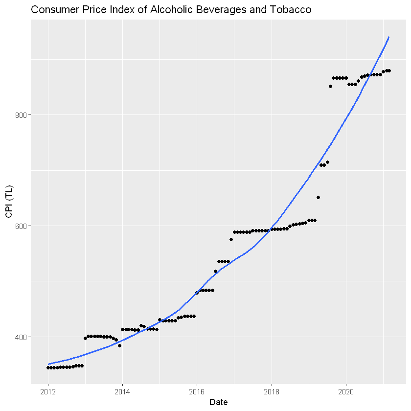

```r
ggplot(alc_tob_cpi ,aes(x=Date,y=CPI)) + geom_point() + geom_smooth(se=FALSE) +
ggtitle("Consumer Price Index of Alcoholic Beverages and Tobacco") + ylab("CPI (TL)")
```

It is obvious that CPI has increased exponentially and the variance of it has been increasing. At some points, it increased suddenly and stayed steady for a some amount of time. This behavior exists mainly throughout the period, and it may cause some autocorrelation problems in the model. The reason of this behavior is that prices of alcohols and tobaccos are steady in general. They are generally fixed and they get raise one time in a year generally. Between 2017 and 2019, the CPI values stayed almost same, then it increased almost 50%. There are also strange observations, such as, in middle of 2019, the CPI changed almost in every month.

There is no seasonality in the data, which means the time-related features do not seem to be necessary. Also, there are some outliers in the data. CPI values may need to be transformed, but it will be done later because the model performance without the transformation should be seen at first.

Now, since it is a non-stationary time series data, trend factor should be added, instead of moving average trend.

```r
alc_tob_cpi = data.table(alc_tob_cpi)
alc_tob_cpi[,trend:=1:.N]
```

Now, a simple linear regression can be constructed as a baseline model.

```
Call:
lm(formula = CPI ~ trend, data = alc_tob_cpi)

Residuals:
     Min       1Q   Median       3Q      Max
-102.772  -44.215   -7.967   48.321  123.008

Coefficients:
            Estimate Std. Error t value Pr(>|t|)
(Intercept) 265.5740    10.8295   24.52   <2e-16 ***
trend         5.1401     0.1679   30.62   <2e-16 ***
---
Signif. codes:  0 '***' 0.001 '**' 0.01 '*' 0.05 '.' 0.1 ' ' 1

Residual standard error: 56.66 on 109 degrees of freedom
Multiple R-squared:  0.8959,	Adjusted R-squared:  0.8949
F-statistic: 937.8 on 1 and 109 DF,  p-value: < 2.2e-16
```

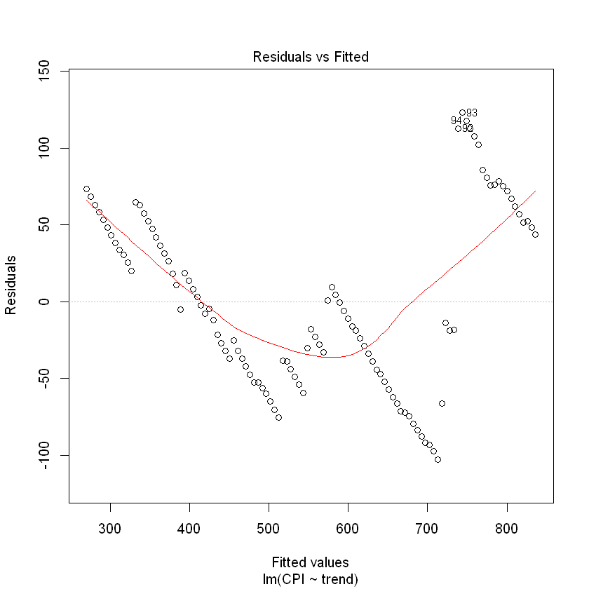

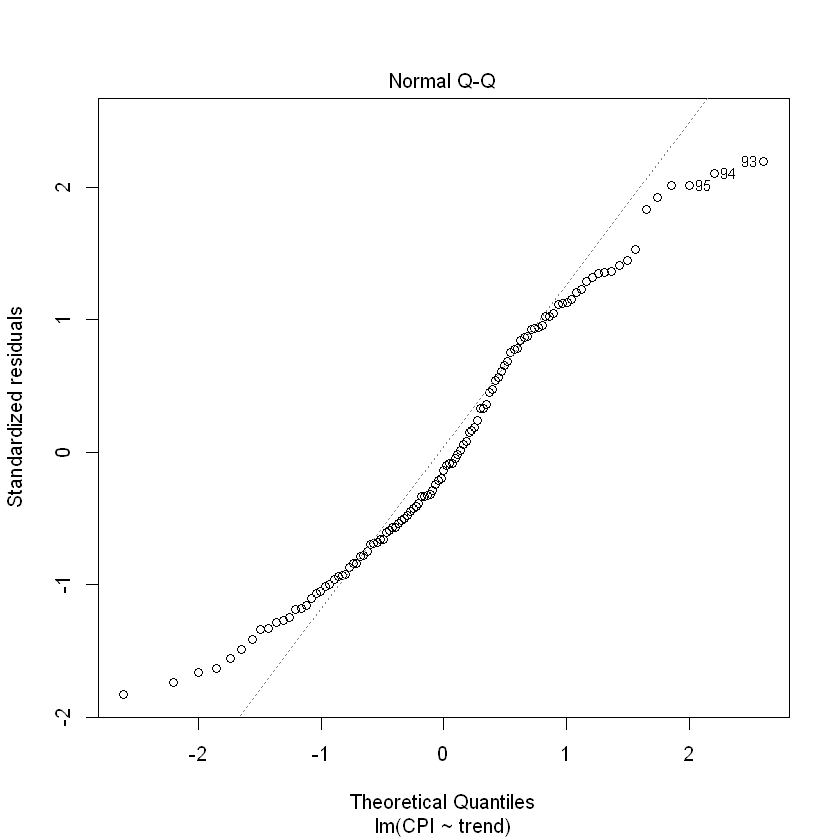

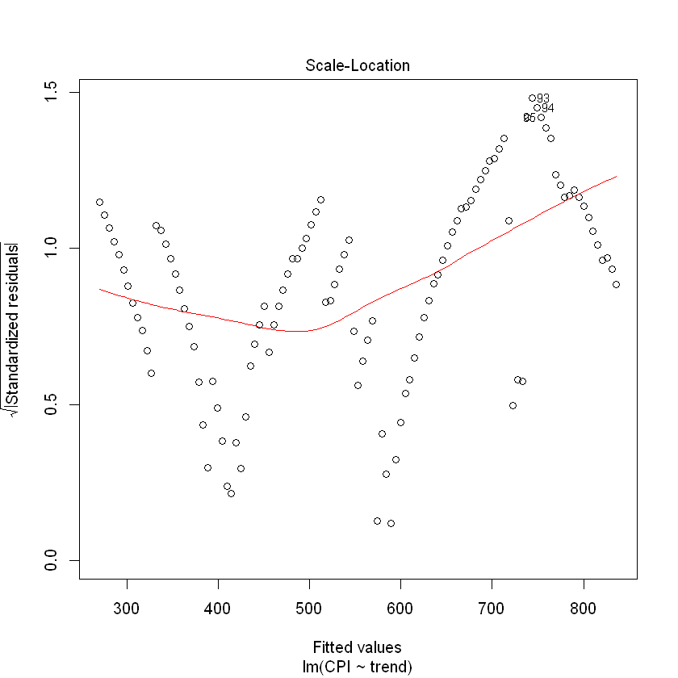

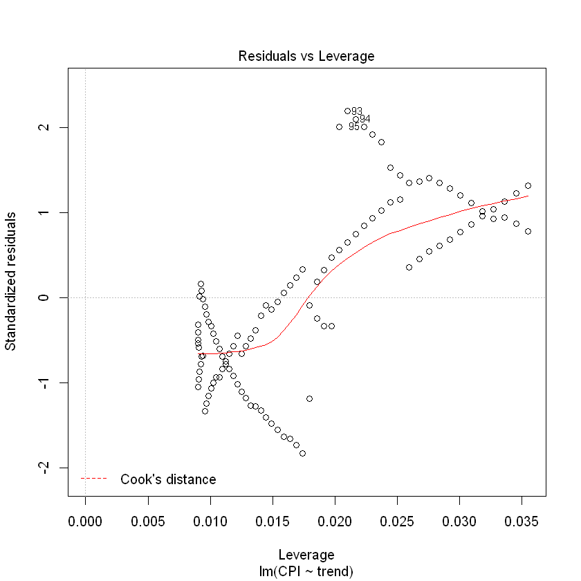

```
	Breusch-Godfrey test for serial correlation of order up to 10

data:  Residuals
LM test = 100.75, df = 10, p-value < 2.2e-16
```

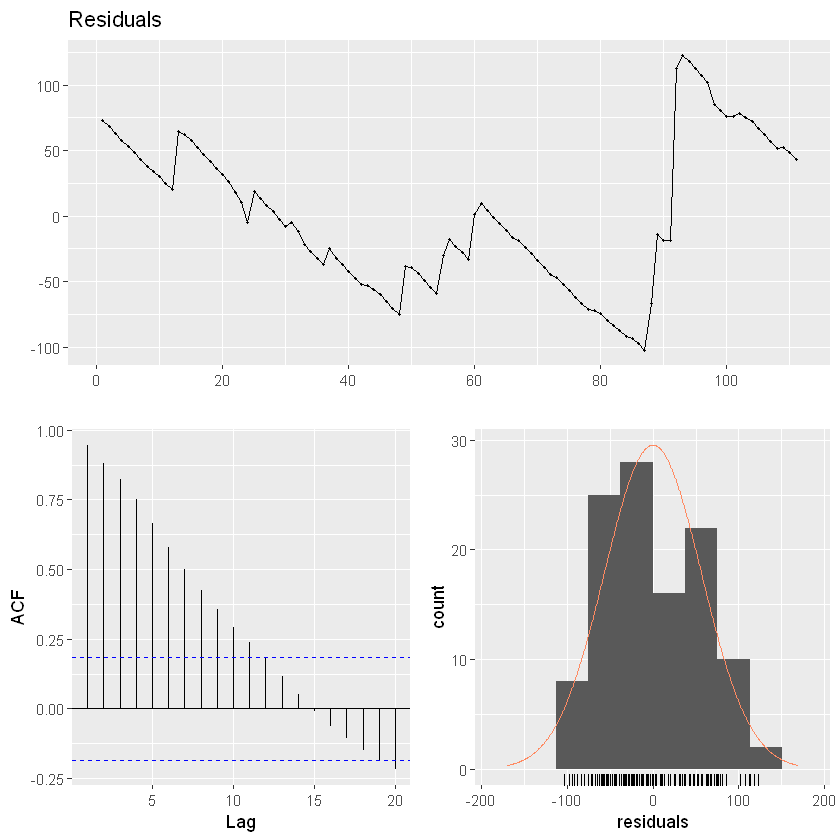

```r
model_1 = lm(CPI~trend, data = alc_tob_cpi)
summary(model_1)
plot(model_1)
checkresiduals(model_1)
```

It can be seen that trend seems statistically significant in this linear regression model, as expected. Adjusted R-squared is very high. Although this high adjusted R-squared value means a good fit, when the residuals and their distribution are checked, it does not give the intended results. Firstly, from the residuals vs. fitted graph, residuals seem to have a nonlinear relationship, rather than linear, which violates the main linearity assumption in linear regression. Secondly, residuals display a seasonal pattern and there is not random distribution on zero mean value. Patterns should have not been in the residual graph. Thirdly, autocorrelation in the residuals is quite high, according to Breusch-Godfrey test. Fourthly and lastly, residuals do not have good normal distribution. These problems will be handled one by one.

Now, firstly, since CPI has increased exponentially, and residuals have a nonlinear relationship with fitted values, another model can be constructed by taking the logarithm of CPI.

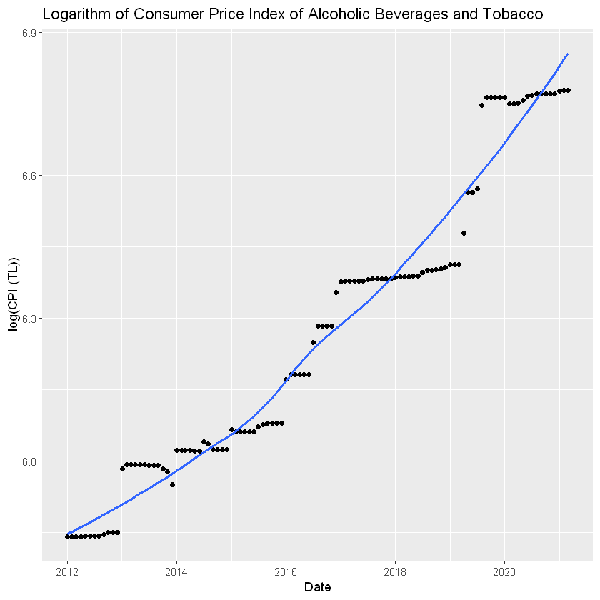

```r
alc_tob_cpi[,log_CPI:=log(CPI)]
ggplot(alc_tob_cpi ,aes(x=Date,y=log_CPI)) + geom_point() + geom_smooth(se=FALSE)+
ggtitle("Logarithm of Consumer Price Index of Alcoholic Beverages and Tobacco") + ylab("log(CPI (TL))")
```

Now, the transformed CPI values seem to be more suitable for the time series regression models. The exponential growth is eliminated here. This transformation can be interpreted easily.

A new model will be constructed by using this new variable.

```
Call:
lm(formula = log_CPI ~ trend, data = alc_tob_cpi)

Residuals:
      Min        1Q    Median        3Q       Max
-0.139362 -0.052442  0.000552  0.047161  0.156997

Coefficients:
             Estimate Std. Error t value Pr(>|t|)
(Intercept) 5.7583816  0.0131350  438.40   <2e-16 ***
trend       0.0091313  0.0002036   44.85   <2e-16 ***
---
Signif. codes:  0 '***' 0.001 '**' 0.01 '*' 0.05 '.' 0.1 ' ' 1

Residual standard error: 0.06873 on 109 degrees of freedom
Multiple R-squared:  0.9486,	Adjusted R-squared:  0.9481
F-statistic:  2012 on 1 and 109 DF,  p-value: < 2.2e-16
```

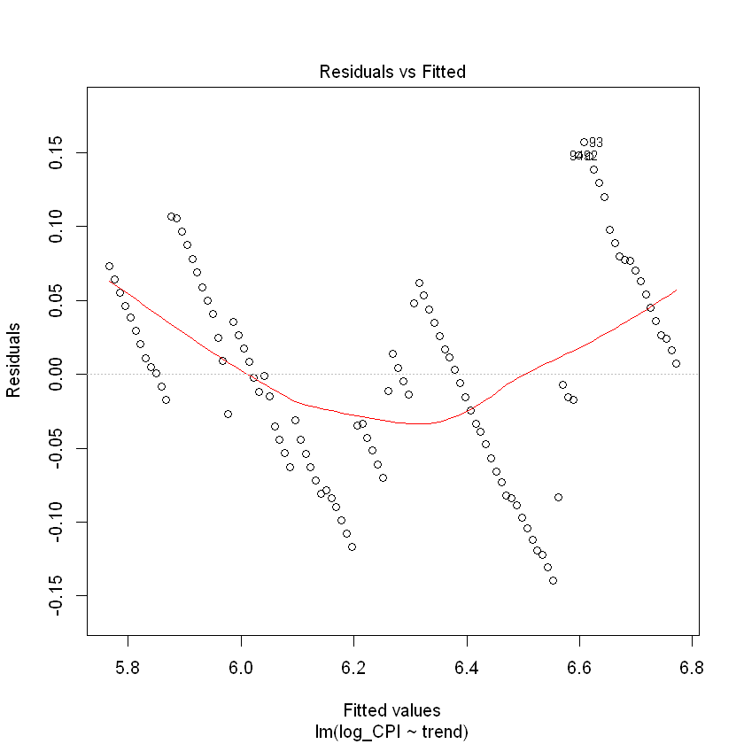

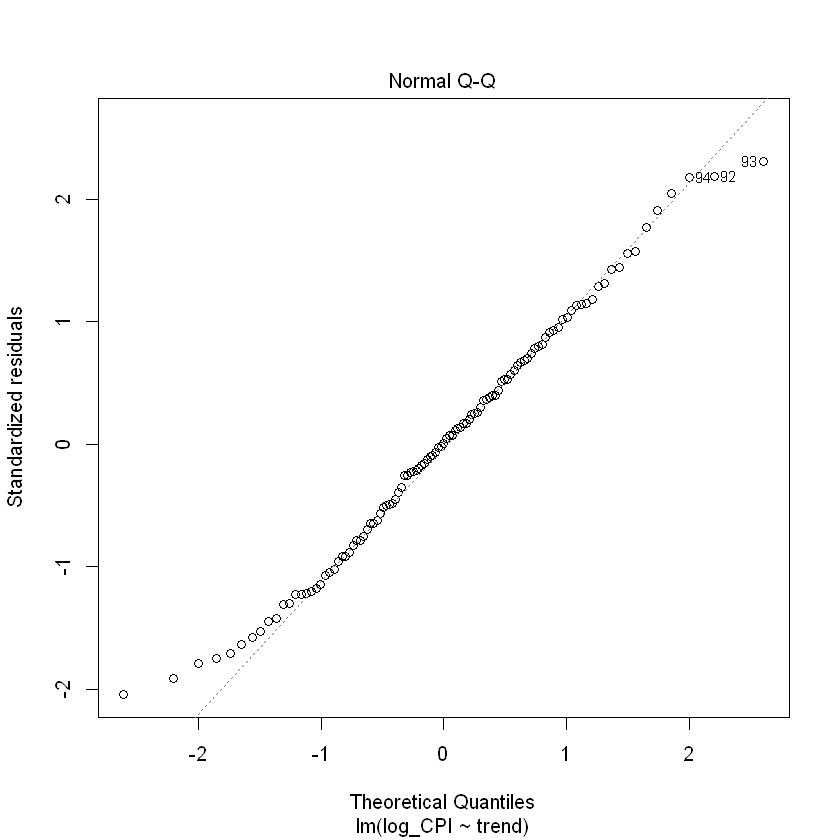

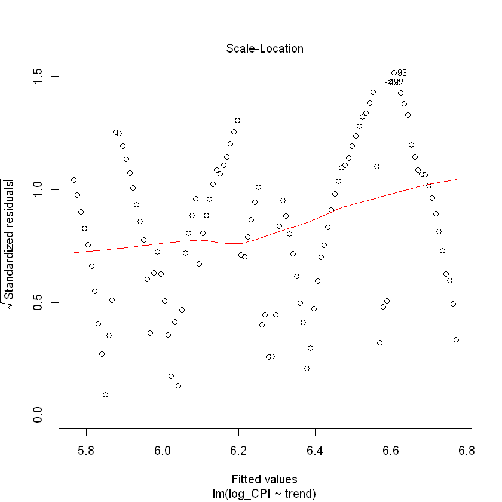

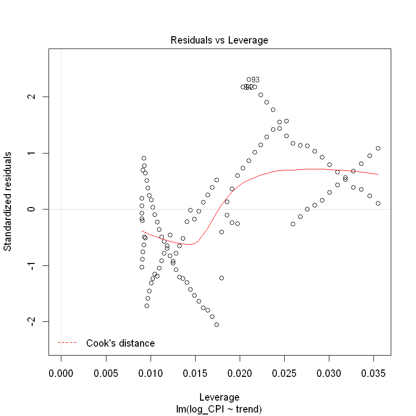

```
	Breusch-Godfrey test for serial correlation of order up to 10

data:  Residuals
LM test = 94.326, df = 10, p-value = 7.4e-16
```

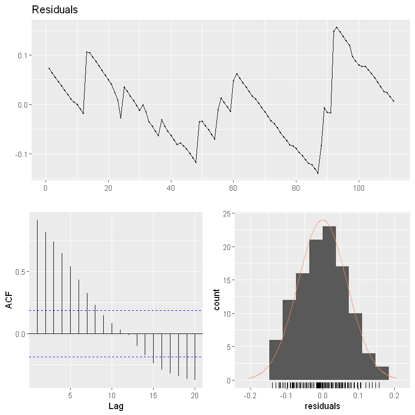

```r
model_2 = lm(log_CPI~trend, data = alc_tob_cpi)
summary(model_2)
plot(model_2)
checkresiduals(model_2)
```

As expected, the model performance increased significantly, according to the adjusted R-squared value. However, residuals do not have a linear relationship, like the model above. Also, the autocorrelation in the residuals still exists, which means there is some information left over in the data. Therefore, the model should be improved by adding new variables from both existing data and the external data.

### Exchange Rate

The data wil be read.

```r
data_path = "C:/Users/Alkim/Desktop/8. Dönem/IE 360/Homework 2/dolar_1.xlsx"
dollar=read.xlsx(data_path,sheet='EVDS')
```

Now, the data will be explored.

```r
head(dollar,5)
tail(dollar,5)
str(dollar)
```

| Tarih | TP.DK.USD.A.YTL |
| --- | --- |
| 2012-01 | 1.838936 |
| 2012-02 | 1.751090 |
| 2012-03 | 1.779295 |
| 2012-04 | 1.779840 |
| 2012-05 | 1.796955 |

|  | Tarih | TP.DK.USD.A.YTL |
| --- | --- | --- |
| 107 | 2020-11 | 8.003324 |
| 108 | 2020-12 | 7.721065 |
| 109 | 2021-01 | 7.393975 |
| 110 | 2021-02 | 7.072365 |
| 111 | 2021-03 | 7.628235 |

```
'data.frame':	111 obs. of  2 variables:
 $ Tarih          : chr  "2012-01" "2012-02" "2012-03" "2012-04" ...
 $ TP.DK.USD.A.YTL: num  1.84 1.75 1.78 1.78 1.8 ...
```

The same operations made for the CPI data will be applied for the exchange rates.

```r
colnames(dollar) <- c("Date", "Dollar")
dollar$Date <- as.Date(paste0(dollar$Date,"-01",sep=""))
```

Now, they will be merged. Then, since we will use lagged variables, the exchange rate should also be lagged.

```r
alc_tob_cpi[,Dollar:=dollar$Dollar]
alc_tob_cpi$Dollar_lagged <- as.numeric(sapply(1:nrow(alc_tob_cpi), function(x) alc_tob_cpi$Dollar[x-1]))
#Since the data are shifted by 1, January-2012 lag-1 variable is NA
                                #It is filled with the next lag-1 variable, February 2012
alc_tob_cpi <- alc_tob_cpi %>% fill(Dollar_lagged, .direction = "up")
```

Since the exchange rate was plotted in the previous homework, it does not have to be plotted. It has an upward trend, like CPI. There are some extreme increases and decreses as well.

Now, another model with trend and dollar will be constructed.

```
Call:
lm(formula = log_CPI ~ trend + Dollar_lagged, data = alc_tob_cpi)

Residuals:
      Min        1Q    Median        3Q       Max
-0.150253 -0.033950 -0.004359  0.040040  0.158530

Coefficients:
               Estimate Std. Error t value Pr(>|t|)
(Intercept)   5.7336535  0.0145688 393.557  < 2e-16 ***
trend         0.0072258  0.0006013  12.017  < 2e-16 ***
Dollar_lagged 0.0356296  0.0106379   3.349  0.00112 **
---
Signif. codes:  0 '***' 0.001 '**' 0.01 '*' 0.05 '.' 0.1 ' ' 1

Residual standard error: 0.06571 on 108 degrees of freedom
Multiple R-squared:  0.9534,	Adjusted R-squared:  0.9526
F-statistic:  1106 on 2 and 108 DF,  p-value: < 2.2e-16
```

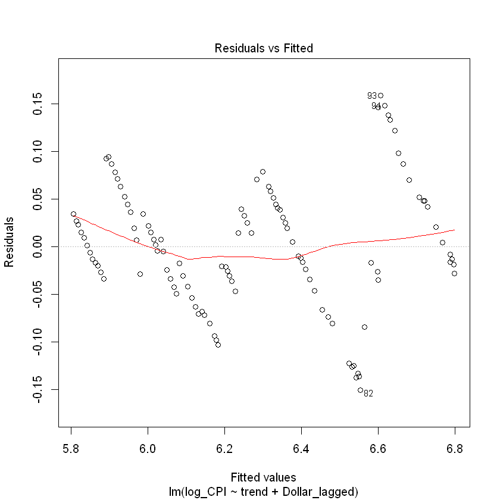

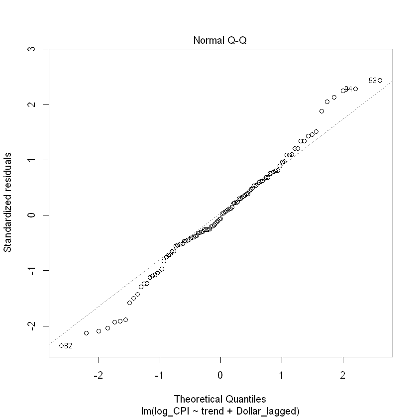

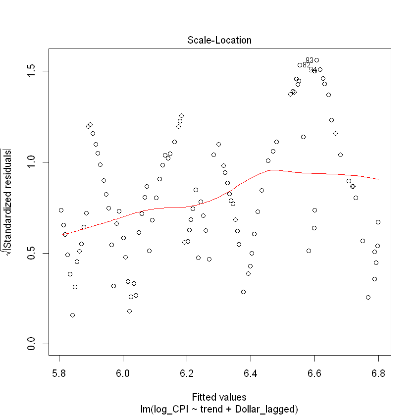

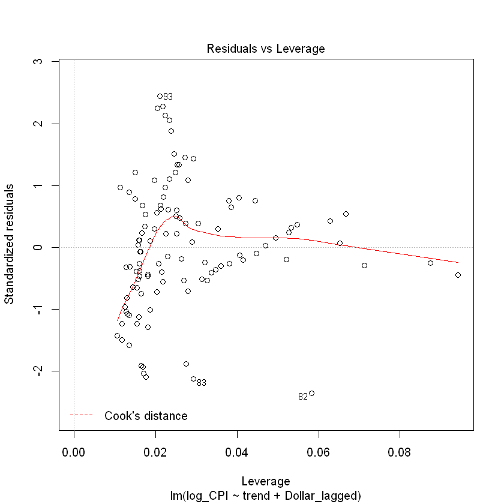

```r
model_3 = lm(log_CPI~trend+Dollar_lagged, data = alc_tob_cpi)
summary(model_3)
plot(model_3)
```

According to p-values of the independent variables, USD-TRY exchange rate seems to be statistically significant on the CPI. There is an improvement in adjusted R-squared. As you can see from the residuals vs. fitted graph, nonlinearity reduced slightly comparet to the previous model, but there is still some non-linearity we should eliminate.

The predicted vs. actual observations plot is below.

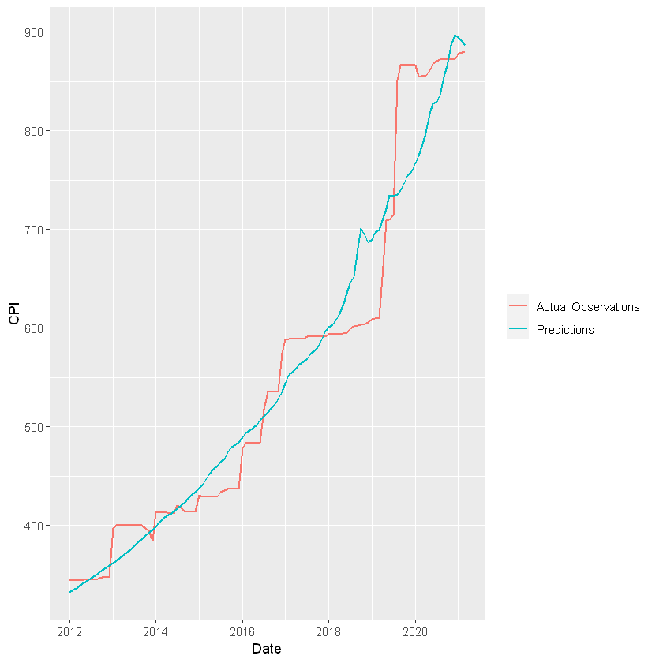

```r
alc_tob_cpi[,predictions:=exp(predict(model_3,alc_tob_cpi))]
ggplot(alc_tob_cpi ,aes(x=Date)) +
        geom_line(aes(y=CPI,color='Actual Observations'), size = 0.8) +
        geom_line(aes(y=predictions,color='Predictions'), size = 0.8) +
        theme(legend.title = element_blank())
```

As you can see, the predictions show a linear behavior. There is no steady periods, as opposed to the actual CPI. The reason is that the exchange rate has been increasing continuously. There has not been a steady period for a year. As it can be seen from the graph, the model cannot predict the sudden jumps in CPI.

For the more detailed exploration, autocorrelation and residual information will be displayed.

```
	Breusch-Godfrey test for serial correlation of order up to 10

data:  Residuals
LM test = 93.525, df = 10, p-value = 1.068e-15
```

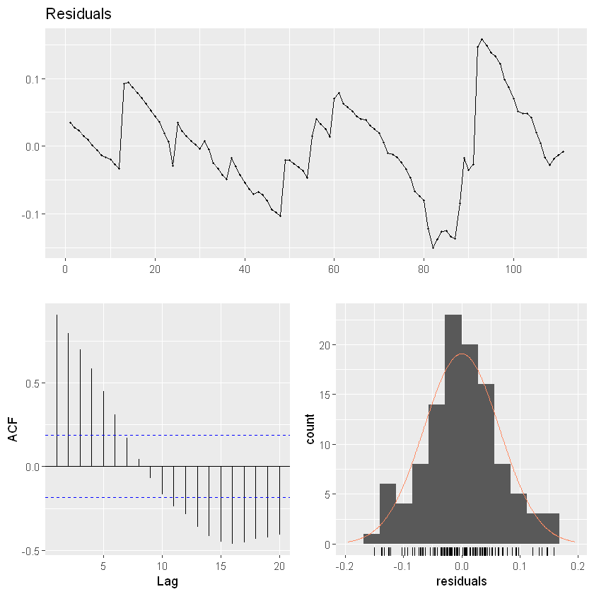

```r
checkresiduals(model_3)
```

Residuals have almost a normal distribution although some discrepancies exist. When the residual graph is analyzed, it can be observed that there are some seasonal patterns, and they are not distributed randomly on zero mean, like the previous model. The autocorrelation in residuals seems to decrease, but it is not enough. Autocorrelation is still high in some lag values It means that the model can be improved by adding new variables. p-value of Breusch-Godfrey is almost 0, which means the null hypothesis is rejected and there is an autocorrelation between residuals.

Now, consumer confidence index will be added.

### Consumer Confidence Index

The Consumer Confidence Index (CCI) is a survey that measures how optimistic or pessimistic consumers are regarding their expected financial situation. This index may reflect the political side of these price changes. Since the prices are determined by the government, it may be negatively correlated with CPI. However, since the data are based on surveys from citizens, the data may not be reliable because the people attending to the survey may be chosen by the government itself, which means the data may be biased.

Now, we will apply the same data operations made above.

```r
data_path = "C:/Users/Alkim/Desktop/8. Dönem/IE 360/Homework 2/confidence_index.xlsx"
trust_index=read.xlsx(data_path,sheet='EVDS')
colnames(trust_index) <- c("Date", "Trust_index")
trust_index$Date <- as.Date(paste0(trust_index$Date,"-01",sep=""))
```

Now, we should plot the customer confidence index before diving into the model in order to see the patterns in the data.

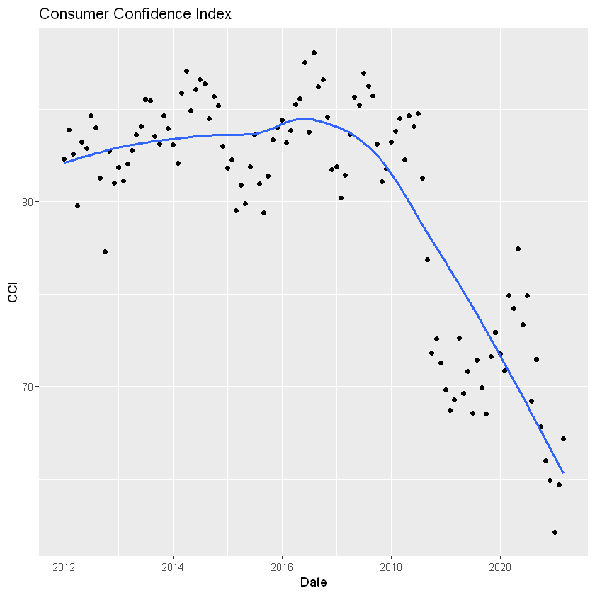

```r
ggplot(trust_index ,aes(x=Date,y=Trust_index)) + geom_point() + geom_smooth(se=FALSE) +
ggtitle("Consumer Confidence Index") + ylab("CCI")
```

It can be realized that consumer confidence index had a slight upward trend from 2012 to 2017. Then, it has decreased since 2017. It seems that there is not an obvious relation between confidence index and CPI. However, we need to construct the model to justify this argument.

Now, they will be merged, then as applied above, the lagged version of it will be used in the model.

```r
alc_tob_cpi[,Trust_index:=trust_index$Trust_index]
alc_tob_cpi$Trust_index_lagged <- as.numeric(sapply(1:nrow(alc_tob_cpi), function(x) alc_tob_cpi$Trust_index[x-1]))
#Since the data are shifted by 1, January-2012 lag-1 variable is NA
                                #It is filled with the next lag-1 variable, February 2012
alc_tob_cpi <- alc_tob_cpi %>% fill(Trust_index_lagged, .direction = "up")
```

Now, the model will be constructed by using trend, lagged versions of the USD-TRY exchange rate and confidence index.

```
Call:
lm(formula = log_CPI ~ trend + Dollar_lagged + Trust_index_lagged,
    data = alc_tob_cpi)

Residuals:
      Min        1Q    Median        3Q       Max
-0.148899 -0.034720 -0.001734  0.044127  0.152147

Coefficients:
                     Estimate Std. Error t value Pr(>|t|)
(Intercept)         5.8835841  0.1848156  31.835   <2e-16 ***
trend               0.0075026  0.0006917  10.847   <2e-16 ***
Dollar_lagged       0.0263743  0.0155843   1.692   0.0935 .
Trust_index_lagged -0.0016409  0.0020163  -0.814   0.4176
---
Signif. codes:  0 '***' 0.001 '**' 0.01 '*' 0.05 '.' 0.1 ' ' 1

Residual standard error: 0.06582 on 107 degrees of freedom
Multiple R-squared:  0.9537,	Adjusted R-squared:  0.9524
F-statistic: 735.1 on 3 and 107 DF,  p-value: < 2.2e-16
```

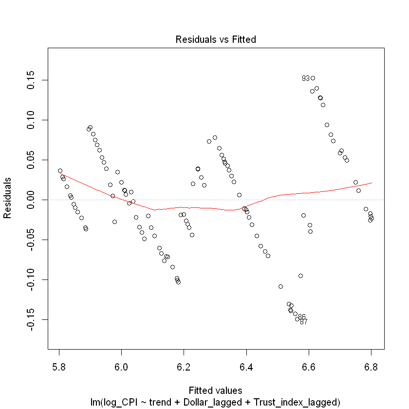

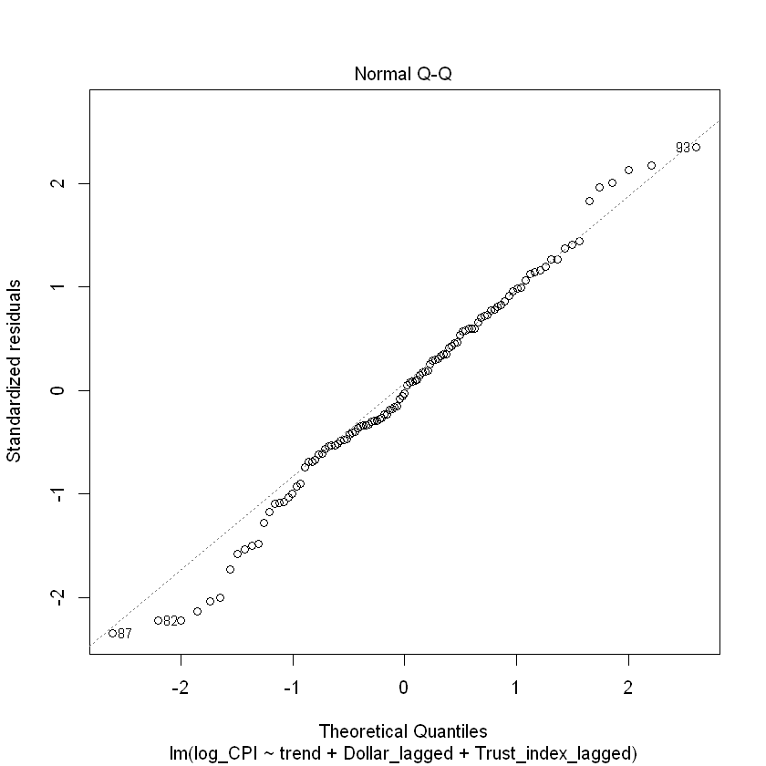

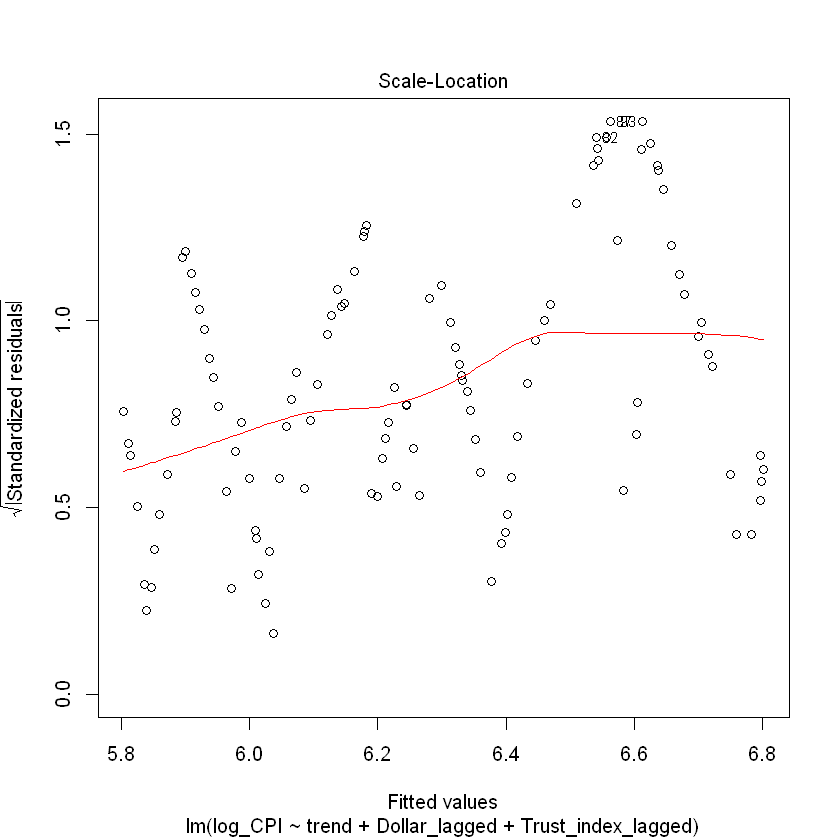

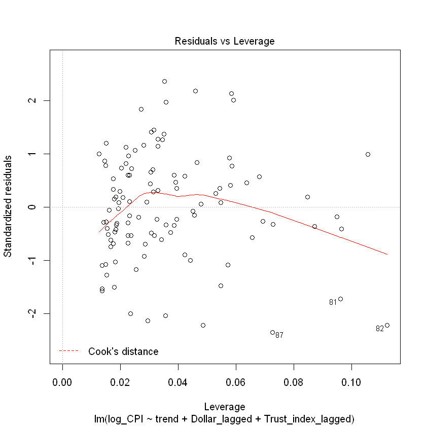

```r
model_4 = lm(log_CPI~trend+Dollar_lagged+Trust_index_lagged, data = alc_tob_cpi)
summary(model_4)
plot(model_4)
```

Customer confidence index does not seem to be helpful for the model. It also affects the significance of the exchange rate variable. Adjusted R-squared is slightly lower, and there is no particular change in plots. It may be said that consumer confidence index is not necessary in our model but we have to check residuals first.

Now, autocorrelation statistics will be analyzed.

```
	Breusch-Godfrey test for serial correlation of order up to 10

data:  Residuals
LM test = 93.973, df = 10, p-value = 8.7e-16
```

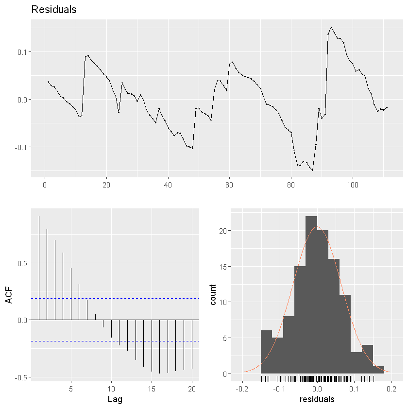

```r
checkresiduals(model_4)
```

p-value of Breusch-Godfrey test is still almost zero, which is significant. Autocorrelation still exists, which can be seen the residuals graph. There is a seasonal pattern. Graphs are almost same as the graphs above. As a result, confidence index should be removed from the model for simplicity.

Now, the search volume of "Sigaraya zam" will be explored.

### Search Volume of "Sigaraya Zam"

As a final external data, the search volume of "sigaraya zam" will be added. It may be helpful for explaining the sudden increases in the price of tobaccos and alcohols because when there is a "zam", it is searched in Google generally to learn the new prices. Since there has not been no decrease in prices, the word of "zam" should be better, rather than "indirim".

The data is imported. Some similar operations made above will be applied.

```r
data_path = "C:/Users/Alkim/Desktop/8. Dönem/IE 360/Homework 2/sigaraya_zam.csv"
zam = read.csv(data_path)
colnames(zam) <- c("Date", "zam")
zam$Date <- as.Date(paste0(zam$Date,"-01",sep=""))
str(zam)
```

```
'data.frame':	111 obs. of  2 variables:
 $ Date: Date, format: "2012-01-01" "2012-02-01" ...
 $ zam : Factor w/ 17 levels "<1","0","1","100",..: 1 2 1 1 10 3 3 1 10 3 ...
```

Since "zam" column is factor, it will be converted to character, then numeric. Also, "<1" will be equal to 0.

```r
zam$zam <- as.character(zam$zam)
zam$zam <- ifelse(zam$zam == "<1",0,zam$zam)
zam$zam <- as.numeric(zam$zam)
```

Before constructing the model, we need to graph the search volume.

The plot is below.

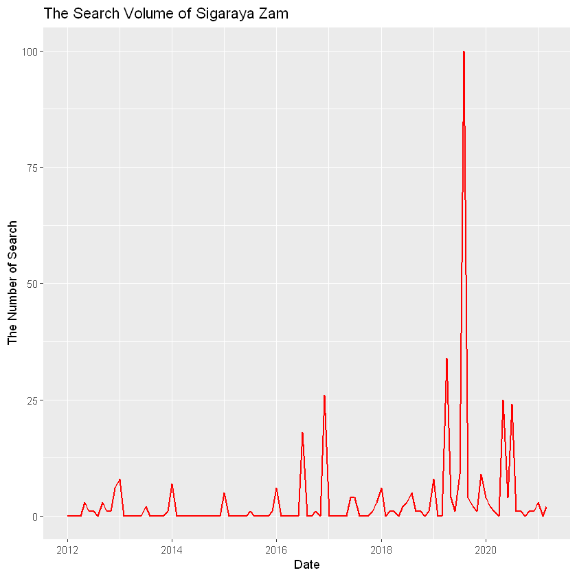

```r
ggplot(zam ,aes(x=Date,y=zam)) + geom_line(color = "red", size = 0.8) +
ggtitle("The Search Volume of Sigaraya Zam") + ylab("The Number of Search")
```

```r
alc_tob_cpi[,zam:=zam$zam]
alc_tob_cpi$zam_lagged <- as.numeric(sapply(1:nrow(alc_tob_cpi), function(x) alc_tob_cpi$zam[x-1]))
#Since the data are shifted by 1, January-2012 lag-1 variable is NA
                                #It is filled with the next lag-1 variable, February 2012
alc_tob_cpi <- alc_tob_cpi %>% fill(zam_lagged, .direction = "up")
```

```
Call:
lm(formula = log_CPI ~ trend + Dollar_lagged + zam_lagged, data = alc_tob_cpi)

Residuals:
      Min        1Q    Median        3Q       Max
-0.140824 -0.033064 -0.002106  0.035399  0.152221

Coefficients:
               Estimate Std. Error t value Pr(>|t|)
(Intercept)   5.7362060  0.0139634 410.804  < 2e-16 ***
trend         0.0071437  0.0005760  12.403  < 2e-16 ***
Dollar_lagged 0.0345086  0.0101858   3.388 0.000987 ***
zam_lagged    0.0018840  0.0005699   3.306 0.001289 **
---
Signif. codes:  0 '***' 0.001 '**' 0.01 '*' 0.05 '.' 0.1 ' ' 1

Residual standard error: 0.06289 on 107 degrees of freedom
Multiple R-squared:  0.9578,	Adjusted R-squared:  0.9566
F-statistic: 808.6 on 3 and 107 DF,  p-value: < 2.2e-16
```

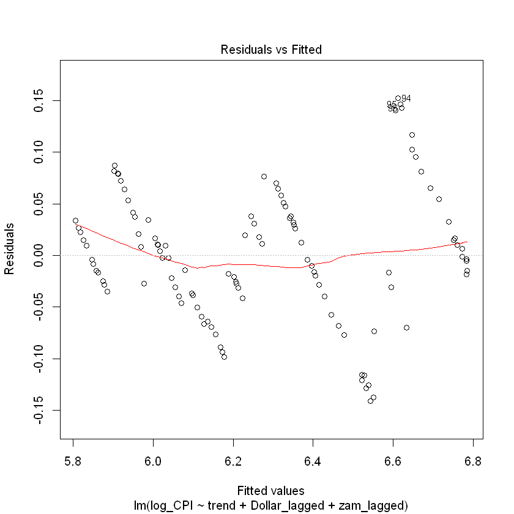

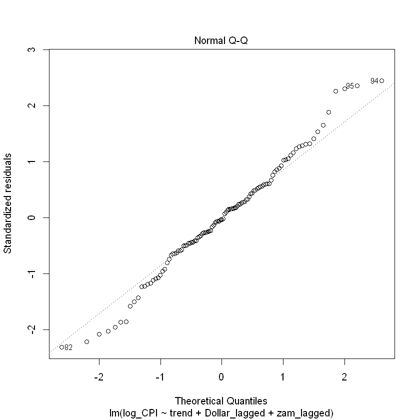

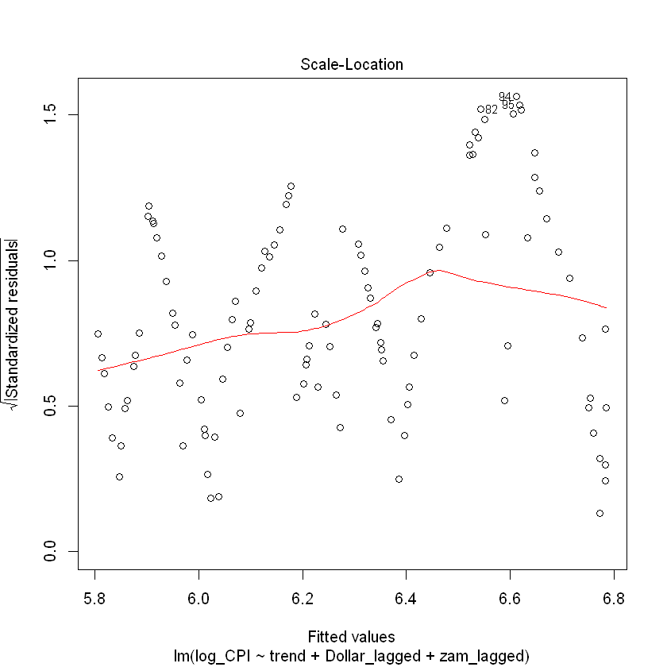

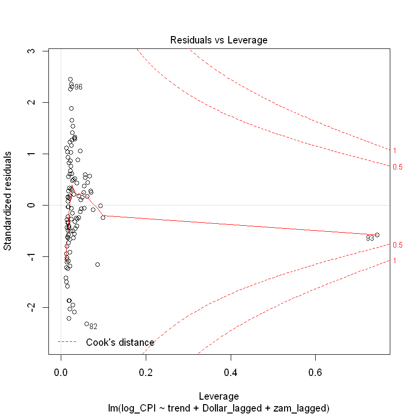

```r
model_5 = lm(log_CPI~trend+Dollar_lagged+zam_lagged, data = alc_tob_cpi)
summary(model_5)
plot(model_5)
```

As it can be seen from the graph, the search volume is statistically significant according to p-value. Adjusted R-squared increased slightly. The residual graphs are very similar to the above graphs. There is no obvious change. It should be noted that there is still some non-linearity in residual vs. fitted graph.

Now, before analyzing the residuals, we need to plot the predictions vs. actual observations to compare.

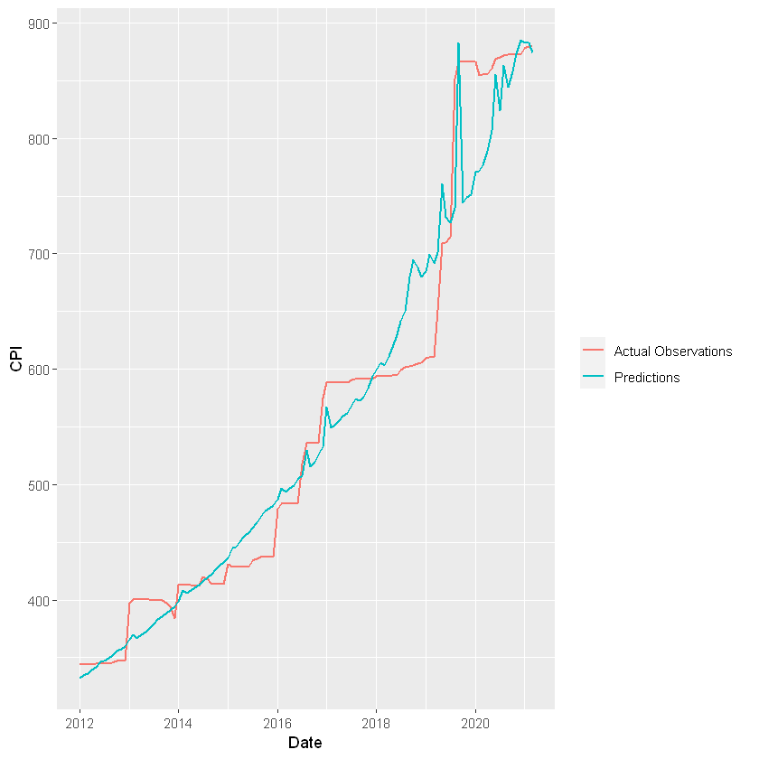

```r
alc_tob_cpi[,predictions:=exp(predict(model_5,alc_tob_cpi))]
ggplot(alc_tob_cpi ,aes(x=Date)) +
        geom_line(aes(y=CPI,color='Actual Observations'), size = 0.8) +
        geom_line(aes(y=predictions,color='Predictions'), size = 0.8) +
        theme(legend.title = element_blank())
```

The analysis for residuals will be discussed now.

```
	Breusch-Godfrey test for serial correlation of order up to 10

data:  Residuals
LM test = 88.841, df = 10, p-value = 9.088e-15
```

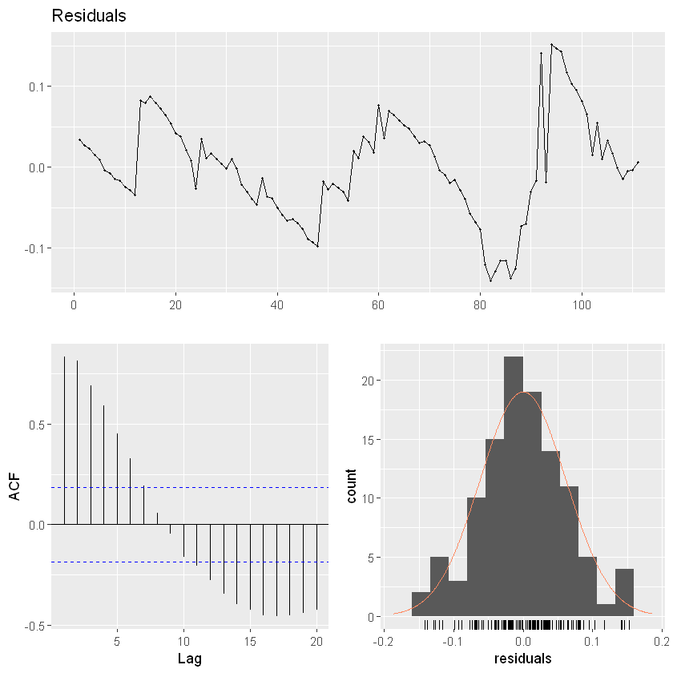

```r
checkresiduals(model_5)
```

Again, according to Breusch-Godfrey, p-value is almost zero, which means there is an autocorrelation in residuals. Residuals show a normal distribution with a zero mean value, but there are some seasonal patterns in residuals. This model is not enough and should be revised.

If the autocorrelation graph is checked, it can be seen that the highest autocorrelation exists in lag-1. Therefore, we can add lag-1 variable into the model.